# On the Frontier of Water Rights: Beneficial Use and Relinquishment in the Wild West and Now

April 24, 2019

## Water rights in the West

### Prior Appropriations Doctrine (G. D. Libecap 2011):

- **Appropriation**: A water right is for a fixed amount for a specific use.
- **Priority**: Seniority is determined by date of claim, with more senior claims being filled first.

## Water rights in the West

### Beneficial use, waste, and forfeiture

- Use should be beneficial.
- An unused portion of a water right cannot later be sold (“use-it-or-lose-it” / relinquishment).

Courts have generally been willing to reduce a right based on historical use to avoid third party harm (Neuman 1998), but have been unwilling to determine what constitutes “beneficial” use.

Importantly, *beneficial use does not include speculation.* (Zellmer 2007)

## The problem

If a right can be reduced based on historical use, rights-holders have an incentive to use more water than optimal to prevent that reduction.

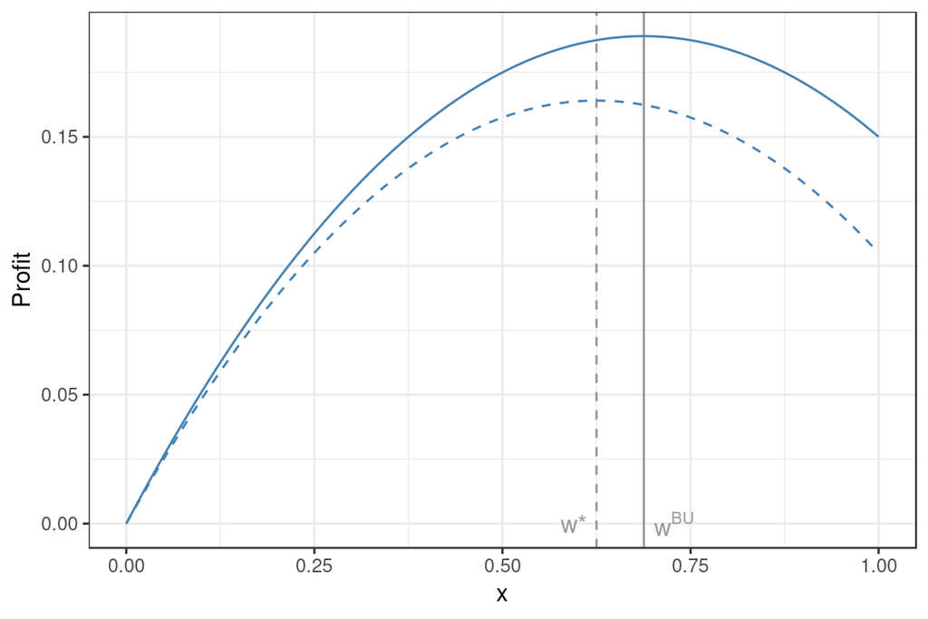

## The (research) question

### What was the economic incentive for beneficial use as a policy, and how does the effect of the policy change as a basin becomes “fully” allocated?

## California

An origin story

## A brief history of mining in CA

A land without property rights (Umbeck 1977):

- **1846**: Mexican-American War Begins. U.S. troops occupy Calinfornia.
- **1848**: Mexican-American War ends. California becomes U.S. territory.
- **1848, 9 days earlier**: gold is discovered.
- **1866**: Right of way for ditches and canals on public land, opened land for claims.

## Property rights if you can’t own land

Mining groups formed a set of rules that generally consisted of (Zerbe and Anderson 2001):

- A claim could be established by filing with the group management.
- A claim had to be worked to be kept.
- A non-worked claim was considered abandoned and could be claimed by someone else.

These serve as the basis for the development of the Prior Appropriation Doctrine (Neuman 1998).

## Water on the Frontier

Abundant land, scarce water

## Prior Appropriations as a solution

Water is a classic common-pool resource: exclusion is difficult and consumption is rivalrous.

- Allocation on priority of right makes water excludable.
- Collective action (Ostrom and Gardner 1993) among cohesive groups and contracts (Leonard and Libecap 2016) among non-cohesive groups solve the problem of investment in community infrastructure.
- But monopolization could impede settlement. Burness and Quirk (1979) assumes monopoly problem is solved.

## Beneficial solves the monopoly problem

**Beneficial use sought to (Zellmer 2007):**

1. Reduce monopoly and speculation behaviors
2. Maximize the use of a scarce resource
3. Allow flexibility of use by users

## Monopoly on the Frontier

Consider a two-period model in which a firm is the first to make a claim at a water source of size \(W\). The firm chooses diversion size \(\bar{w}\) to maximize profits

\[\max \limits_{\bar{w_1}, w_1} (1+\delta)\left[p_w(w_1)w_1 - c^t(w_1)\right] - C(\bar{w_1}) \\ \mbox{ s.t. } w_1 \le \bar{w}_1, \bar{w}_1 \le W\]

where: - \(C(\bar{w}_1)\) is the cost of diversion investment - \(p_w(w_1)\) is the inverse demand for water - \(w_1\) is the water sold by the firm

Assume \(p_w(w_1^*) > MV_w\) so the firm has no interest in farming, and \(\bar{w}_1^* = W\) so that a single firm monopolizes the entire water source.

Then under the standard monopoly argument \(p_w(w^*_1) > p^*_w\) and water supplied \(w_1 < w^*\).

## Beneficial Use on the Frontier

Firm \(i\) can only sell water for which it has established use, so the maximization problem becomes

\[\max \limits_{\bar{w}_i, w_i} y(w_i) - c(w_i) + \delta p_w(\sum_j w_j) w_i - C(\bar{w_i}) \mbox{, s.t. } w_i \le \bar{w}_i,\]

where: - The firm may choose \(\bar{w}_i < W\), so price depends on all provided water \(\sum_j w_j\) - \(y(w_i)\) is the yield and \(c(w_i)\) is the cost of irrigation

Then given land claim limits (~160 acres), the number of firms \(n\) is large enough that the market becomes competitive and \(\sum w_j = W\).

## A Model of Beneficial Use Now

Fast-forwarding to now. A firm owns paper water right \(\bar{w}\), and knows that in the second period \(p_w > MV_w\). The maximization problem is

\[\max \limits_{w} y(w) - cw + \delta p_w w \mbox{, s.t. } w \le \bar{w}\]

If \(y(w)\) is inverse U-shaped, then \(w^{BU} > w^*\), and beneficial use results in irrigation with more water than is optimal.

In contrast, if the firm can sell their enitre water right in the second period, their water use is \(w^*\). *Note however, that the resulting use in subsequent periods would result in less water available for more junior rights.*

## Directions

- McCall job search?
- heterogeneous land productivity?

## References

Burness, H Stuart, and James P Quirk. 1979. “Appropriative Water Rights and the Efficient Allocation of Resources.” *The American Economic Review* 69 (1). JSTOR:25–37.

Leonard, Bryan, and Gary Libecap. 2016. “Collective Action by Contract: Prior Appropriation and the Development of Irrigation in the Western United States.” National Bureau of Economic Research. https://doi.org/10.3386/w22185.

Libecap, Gary D. 2011. “Institutional Path Dependence in Climate Adaptation: Coman’s ‘Some Unsettled Problems of Irrigation’.” *American Economic Review* 101 (1). American Economic Association:64–80. https://doi.org/10.1257/aer.101.1.64.

Neuman, Janet C. 1998. “Beneficial Use, Waste, and Forfeiture: The Inefficient Search for Efficiency in Western Water Use.” *Envtl. L.* 28. HeinOnline:919.

Ostrom, Elinor, and Roy Gardner. 1993. “Coping with Asymmetries in the Commons: Self-Governing Irrigation Systems Can Work.” *Journal of Economic Perspectives* 7 (4). American Economic Association:93–112. https://doi.org/10.1257/jep.7.4.93.

Umbeck, John. 1977. “The California Gold Rush: A Study of Emerging Property Rights.” *Explorations in Economic History* 14 (3). Elsevier:197–226.

Zellmer, Sandra. 2007. “The Anti-Speculation Doctrine and Its Implications for Collaborative Water Management.” *Nevada Law Journal* 8:994.

Zerbe, Richard O, and C Leigh Anderson. 2001. “Culture and Fairness in the Development of Institutions in the California Gold Fields.” *The Journal of Economic History* 61 (1). Cambridge University Press:114–43.